# Simulate from Emperical Bayes Estimates

Metrum Research Group, LLC

# Packages

```r
source("libPaths.R")
library(readr)
library(dplyr)
library(mrgsolve)
library(magrittr)

a <- config::get()
source(a$functions)
knitr_config()
```

# Objective

for each individual in the study, get the model-predicted Cmin, Cmax, and AUC at steady state for the randomized dose administration

# Load input data

## Load the meropenem partab file

```r
tab <- read_table(a$mero_partab, skip=1)
```

We create a data frame with one ID per row including each individual’s PK parameters

```r
idata <- distinct(tab,ID,CL,V1,Q,V2)
```

## Load the meropenem data set

```r
data <- read_csv(a$mero_datafile, na='.')
names(data)[1] <- "ID"
```

And do some grooming - Take only dosing records - meropenem is dosing every 8 hours - simulate a total of 12 doses - for IV administration, pick compartment 2

```r
dose <- filter(data, EVID==1)

dose %<>% mutate(II=8, ADDL=11, CMT=2)
```

```r
count(dose,AMT,RATE)
```

```
. # A tibble: 6 x 3
.     AMT      RATE     n
.   <int>     <dbl> <int>
. 1   500  166.6667    13
. 2   500 1000.0000    14
. 3  1000  333.3333    13
. 4  1000 2000.0000    13
. 5  2000  666.6667    13
. 6  2000 4000.0000    13
```

## Join the data set with the individual parameters

```r
data <- left_join(dose,idata)

head(data)
```

```
. # A tibble: 6 x 18
.      ID  TIME GROUP    DV   MDV  EVID   AMT  RATE      AGE       WT  CLCR
.   <dbl> <dbl> <int> <dbl> <int> <int> <int> <dbl>    <dbl>    <dbl> <int>
. 1     1     0     1    NA     1     1   500  1000 29.73503 63.78909    83
. 2     2     0     1    NA     1     1   500  1000 28.20042 54.23259    83
. 3     3     0     1    NA     1     1   500  1000 36.33755 90.05991    83
. 4     4     0     1    NA     1     1   500  1000 35.51446 65.35890    83
. 5     5     0     1    NA     1     1   500  1000 27.44198 59.75195    83
. 6     6     0     1    NA     1     1   500  1000 60.93508 51.36042    83
. # ... with 7 more variables: II <dbl>, ADDL <dbl>, CMT <dbl>, CL <dbl>,
. #   V1 <dbl>, Q <dbl>, V2 <dbl>
```

This is important: we derive a `DOSE` column so that we can work with the simulated data according to dose group later on

```r
data %<>% mutate(DOSE = AMT, DUR = AMT/RATE)
```

# Load a 2-cmt model

Just take a model from the library

```r
mod <- mread("pk2", modlib())

see(mod)
```

```
.
. Model file:  pk2.cpp
.  $PARAM @annotated
.  CL   :  1 : Clearance (volume/time)
.  V2   : 20 : Central volume (volume)
.  Q    :  2 : Inter-compartmental clearance (volume/time)
.  V3   : 10 : Peripheral volume of distribution (volume)
.  KA   :  1 : Absorption rate constant (1/time)
.
.  $CMT @annotated
.  EV     : Extravascular compartment (mass)
.  CENT   : Central compartment (mass)
.  PERIPH : Peripheral compartment (mass)
.
.  $GLOBAL
.  #define CP (CENT/V2)
.
.  $PKMODEL ncmt = 2, depot = TRUE
.
.  $CAPTURE @annotated
.  CP : Plasma concentration (mass/time)
.
```

Check the parameters for this model

```r
param(mod)
```

```
.
.  Model parameters (N=5):
.  name value . name value
.  CL   1     | V2   20
.  KA   1     | V3   10
.  Q    2     | .    .
```

We should inventory the parameters in the model against what is in the data set

```r
inventory(mod,data)
```

Easy enough to fix

```r
data %<>% rename(V3 = V2, V2 = V1) %>% mutate(V1 = NULL)

inventory(mod,data)
```

The model we are using includes a extravascular dosing compartment with first order absorption controlled by parameter `KA`. Our drug is administered `IV` so it’s ok that we’re missing `KA` in the data set.

Not required … but I update the model with the parameters from the first individual to have a set of “valid” parameters in the model. Sometimes this helps when trying to get a sense check about whether the simulation is set up correctly or not.

```r
mod %<>% update(param=data[1,])
```

```r
des <- tgrid(0, 24, 0.5) + 3*24
```

In the `mrgsim` call, let’s ask for `DOSE`, `DUR` and `CL` in the simulated output.

```r
count(data,DOSE,AMT,DUR)
```

```
. # A tibble: 6 x 4
.    DOSE   AMT   DUR     n
.   <int> <int> <dbl> <int>
. 1   500   500   0.5    14
. 2   500   500   3.0    13
. 3  1000  1000   0.5    13
. 4  1000  1000   3.0    13
. 5  2000  2000   0.5    13
. 6  2000  2000   3.0    13
```

What would happen if we asked for `AMT` instead of `DOSE` here?

```r
out <- mrgsim(mod, carry.out="DOSE,DUR,CL",
              data=data, tgrid=des, obsonly=TRUE)
```

```r
head(out)
```

```
. Model:  pk2
```

```
.   ID TIME DOSE DUR     CL EV       CENT     PERIPH         CP
. 1  1 72.0  500 0.5 13.394  0   3.803242   6.917929  0.3686027
. 2  1 72.5  500 0.5 13.394  0 288.793045 109.620106 27.9892464
. 3  1 73.0  500 0.5 13.394  0 122.268995 156.428825 11.8500674
. 4  1 73.5  500 0.5 13.394  0  80.120076 135.264236  7.7650781
. 5  1 74.0  500 0.5 13.394  0  60.943789 109.192241  5.9065506
. 6  1 74.5  500 0.5 13.394  0  47.981584  87.012618  4.6502795
```

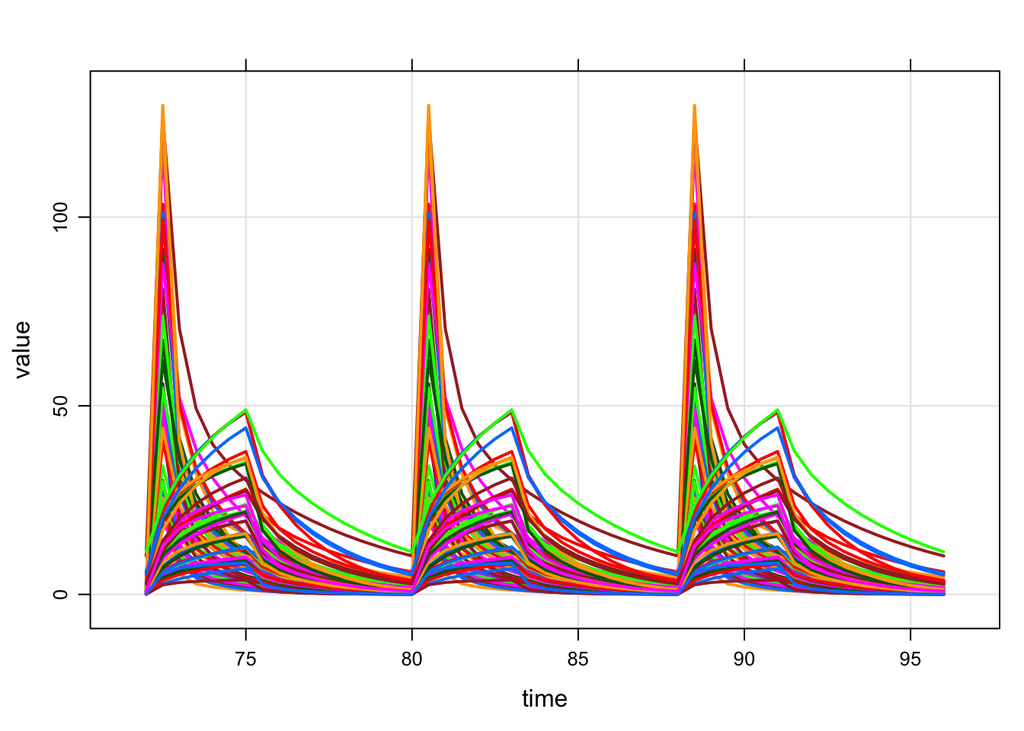

```r
plot(out,CP~.)
```

So, let’s summarize.

```r
sims <- as_data_frame(out)
```

Calculate `AUC` by trapezoidal rule

```r
auc <-
  sims %>%
  AUC(., dv = "CP") %>%
  dplyr::rename(tAUC = AUC) %>%
  as_data_frame
```

```r
auc
```

```
. # A tibble: 79 x 2
.       ID      tAUC
.    <dbl>     <dbl>
.  1     1 111.99044
.  2     2  96.90548
.  3     3  85.71918
.  4     4 119.06652
.  5     5  59.57582
.  6     6 175.10477
.  7     7 108.76659
.  8     8 121.66437
.  9     9 105.04202
. 10    10  77.49935
. # ... with 69 more rows
```

Recall that we carried `CL` into the simulated data. Let’s calculate `AUC` through `CL` and `DOSE` to see how it matches up

```r
auc2 <-
  sims %>%
  distinct(ID,DOSE,CL) %>%
  mutate(pAUC = 3*DOSE/CL) %>%
  ungroup

auc2
```

```
. # A tibble: 79 x 4
.       ID  DOSE      CL      pAUC
.    <dbl> <dbl>   <dbl>     <dbl>
.  1     1   500 13.3940 111.99044
.  2     2   500 15.4790  96.90548
.  3     3   500 17.4990  85.71918
.  4     4   500 12.5980 119.06652
.  5     5   500 25.1780  59.57582
.  6     6   500  8.5663 175.10477
.  7     7   500 13.7910 108.76659
.  8     8   500 12.3290 121.66437
.  9     9   500 14.2800 105.04202
. 10    10   500 19.3550  77.49935
. # ... with 69 more rows
```

Calculate `Cmin` and `Cmax`

```r
minmax <- sims %>%
  group_by(ID,DOSE,DUR) %>%
  summarise(Cmin = min(CP), Cmax = max(CP)) %>%
  ungroup

minmax
```

```
. # A tibble: 79 x 5
.       ID  DOSE   DUR       Cmin     Cmax
.    <dbl> <dbl> <dbl>      <dbl>    <dbl>
.  1     1   500   0.5 0.36860268 27.98925
.  2     2   500   0.5 0.24687879 24.87659
.  3     3   500   0.5 0.25383755 23.87022
.  4     4   500   0.5 0.69103830 23.48125
.  5     5   500   0.5 0.06992704 23.63169
.  6     6   500   0.5 1.09212078 34.07386
.  7     7   500   0.5 0.69898400 30.19700
.  8     8   500   0.5 0.54289711 27.55154
.  9     9   500   0.5 0.47855135 18.96082
. 10    10   500   0.5 0.18614336 24.24134
. # ... with 69 more rows
```

Join together and re-shape

```r
sum <- left_join(auc, minmax) %>% left_join(.,auc2)

summ <- tidyr::gather(sum, variable, value, c(tAUC,pAUC,Cmin,Cmax))
```

# Summary of exposure metrics

```r
summ %>%
  ungroup %>%
  group_by(DOSE,DUR,variable) %>%
  summarise(Med = median(value),
            Mean = mean(value),
            Min = min(value),
            Max = max(value),
            N=n())  %>% as_data_frame
```

```
. # A tibble: 24 x 8
.     DOSE   DUR variable         Med        Mean         Min        Max
.    <dbl> <dbl>    <chr>       <dbl>       <dbl>       <dbl>      <dbl>
.  1   500   0.5     Cmax  24.5589642  25.8235111 18.96081919  34.073858
.  2   500   0.5     Cmin   0.4235770   0.6870022  0.03206795   3.384693
.  3   500   0.5     pAUC 106.9043019 114.6315659 59.57582016 218.623836
.  4   500   0.5     tAUC 106.9043019 114.6315657 59.57582016 218.623833
.  5   500   3.0     Cmax   8.9306285   9.3873075  3.79899884  12.574414
.  6   500   3.0     Cmin   0.6096205   0.7866047  0.03208532   1.940661
.  7   500   3.0     pAUC  95.2441425 104.1431192 35.64215279 154.894672
.  8   500   3.0     tAUC  95.2441425 104.1431191 35.64215278 154.894672
.  9  1000   0.5     Cmax  51.0383087  50.8390631 40.22526641  67.417624
. 10  1000   0.5     Cmin   0.4205332   1.0580385  0.04042681   4.574641
. # ... with 14 more rows, and 1 more variables: N <int>
```